# 03 — The Distance Premium

# 5. SG Component Importance (Standardized Betas)

Since `sg_total` is essentially the sum of its four components (section 2.1), regressing it on all four **will** produce R² close to 1 by construction — that’s expected, not a modeling success. The informative part is the *relative size* of the four standardized betas: which component of the game actually drives the variation in total score, and has that mix shifted toward off-the-tee (where distance lives)?

```r
beta_by_year <- df_main %>%
  group_by(year) %>%
  mutate(across(c(sg_ott, sg_apr, sg_arg, sg_putt), ~as.numeric(scale(.x)), .names = "z_{.col}")) %>%
  group_modify(~{
    fit <- lm(sg_total ~ z_sg_ott + z_sg_apr + z_sg_arg + z_sg_putt, data = .x)
    tibble(term = names(coef(fit))[-1], beta = coef(fit)[-1], r2 = summary(fit)$r.squared)
  }) %>%
  ungroup() %>%
  mutate(component = str_remove(term, "^z_sg_"))

cat("R2 range across years (expected to be ~1):\n")
```

```
## R2 range across years (expected to be ~1):
```

```r
print(range(beta_by_year$r2))
```

```
## [1] 0.9813622 1.0000000
```

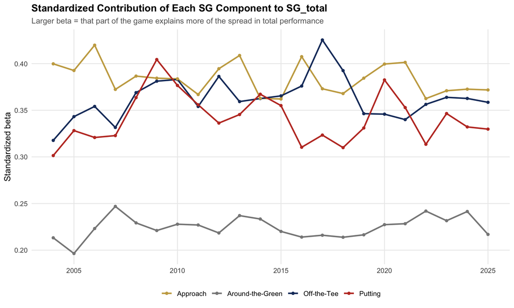

```r
component_labels <- c(ott = "Off-the-Tee", apr = "Approach", arg = "Around-the-Green", putt = "Putting")

p_components <- ggplot(beta_by_year, aes(year, beta, color = component)) +
  geom_line(linewidth = 1) +
  geom_point() +
  scale_color_manual(values = c(
    ott = COL_PRIMARY, apr = COL_SECONDARY, arg = COL_NEUTRAL, putt = COL_ACCENT
  ), labels = component_labels) +
  labs(
    title    = "Standardized Contribution of Each SG Component to SG_total",
    subtitle = "Larger beta = that part of the game explains more of the spread in total performance",
    x = NULL, y = "Standardized beta", color = NULL
  ) +
  THEME_BASE

p_components
```

```r
ott_2004 <- beta_by_year %>% filter(year == min(year), component == "ott") %>% pull(beta)
ott_2025 <- beta_by_year %>% filter(year == max(year), component == "ott") %>% pull(beta)
apr_2004 <- beta_by_year %>% filter(year == min(year), component == "apr") %>% pull(beta)
apr_2025 <- beta_by_year %>% filter(year == max(year), component == "apr") %>% pull(beta)
top_2025 <- beta_by_year %>% filter(year == max(year)) %>% slice_max(beta, n = 1) %>% pull(component)
```

**Finding:** R² is indeed ~1 in every year (as expected — this confirms the components decompose the total cleanly, it’s not a meaningful model-fit result). Approach play (`apr`) has the largest standardized beta in both 2004 (0.4) and 2025 (0.37) — it’s still the single biggest driver of who separates from the pack on `sg_total`, contrary to what a pure “distance premium” narrative alone might suggest. But off-the-tee’s beta rose from 0.32 to 0.36, the largest increase of any component, narrowing the gap with approach considerably. The game hasn’t become “all about the driver,” but the driver’s relative importance has clearly grown.

# 6. Distance Quintile SG_total Trajectories

Using the field-relative distance quintiles already engineered in `00_data_engineering.Rmd` (`dist_quintile`, 1 = shortest, 5 = longest) — a grouped, less noisy view of the same relationship as sections 3/7.

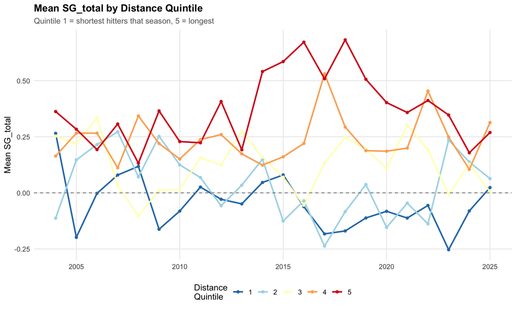

```r
quintile_traj <- df_main %>%
  group_by(year, dist_quintile) %>%
  summarise(mean_sg_total = mean(sg_total, na.rm = TRUE), .groups = "drop")

p_quintiles <- ggplot(quintile_traj, aes(year, mean_sg_total, color = factor(dist_quintile))) +
  geom_line(linewidth = 1) +
  geom_point() +
  geom_hline(yintercept = 0, linetype = "dashed", color = "grey50") +
  scale_color_manual(values = COL_QUINTILES, name = "Distance\nQuintile") +
  labs(
    title    = "Mean SG_total by Distance Quintile",
    subtitle = "Quintile 1 = shortest hitters that season, 5 = longest",
    x = NULL, y = "Mean SG_total"
  ) +
  THEME_BASE

p_quintiles
```

```r
gap_by_year <- quintile_traj %>%
  filter(dist_quintile %in% c(1, 5)) %>%
  pivot_wider(names_from = dist_quintile, values_from = mean_sg_total, names_prefix = "q") %>%
  mutate(gap = q5 - q1)

any_reversed <- sum(gap_by_year$gap < 0)
gap_early <- gap_by_year %>% filter(year <= 2013) %>% summarise(m = mean(gap)) %>% pull(m)
gap_late  <- gap_by_year %>% filter(year >= 2014) %>% summarise(m = mean(gap)) %>% pull(m)
```

**Finding:** the middle quintiles (2-4) aren’t always perfectly ordered in a given year, but the top quintile (Q5, longest) beats the bottom quintile (Q1, shortest) in **every single year** of the dataset (0 reversals out of 22 years). The gap has clearly widened: averaging 0.27 SG in 2004-2013 vs. 0.54 in 2014-2025 — a clean, independent confirmation that the longest hitters’ advantage over the shortest has grown, matching the pooled model result in the next section.

# 7. Interaction Model: The Rigorous Test

Sections 3-6 all point the same direction but are either noisy (3, 4) or descriptive rather than inferential (6). This model pools every player-season, controls for player-level heterogeneity with a random intercept and for age, and tests the distance-premium trend directly via a `dist_vs_field:year` interaction. `dist_vs_field` is rescaled to `dist_vs_field_10` (per 10 yards) so coefficients are directly interpretable as “SG per 10 yards above the field,” and `year` is centered at its median so the main `dist_vs_field_10` effect describes the premium at a typical year in the sample, not a linear extrapolation back to year 0.

```r
df_model <- df_main %>%
  mutate(
    dist_vs_field_10 = dist_vs_field / 10,
    year_c = year - median(year)
  )

fit_interaction <- lmer(
  sg_total ~ dist_vs_field_10 * year_c + age + (1 | player_name),
  data = df_model
)

tidy(fit_interaction, effects = "fixed") %>% print()
```

```
## # A tibble: 5 × 5
##   effect term                    estimate std.error statistic
##   <chr>  <chr>                      <dbl>     <dbl>     <dbl>
## 1 fixed  (Intercept)              0.132     0.0833       1.58
## 2 fixed  dist_vs_field_10         0.211     0.0182      11.6
## 3 fixed  year_c                  -0.00751   0.00215     -3.49
## 4 fixed  age                     -0.00567   0.00242     -2.35
## 5 fixed  dist_vs_field_10:year_c  0.00868   0.00202      4.31
```

```r
coefs <- tidy(fit_interaction, effects = "fixed")
premium_center <- coefs$estimate[coefs$term == "dist_vs_field_10"]
premium_trend  <- coefs$estimate[coefs$term == "dist_vs_field_10:year_c"]
premium_trend_t <- coefs$statistic[coefs$term == "dist_vs_field_10:year_c"]

year_span <- (max(df_model$year) - min(df_model$year)) / 2
premium_2004 <- premium_center - premium_trend * year_span
premium_2025 <- premium_center + premium_trend * year_span
```

**Finding:** this is the test that actually resolves the question. The `dist_vs_field_10:year_c` interaction is 0.0087 (t = 4.31) — small per year, but real and statistically clear once pooled across ~4,000 player-seasons. At the sample’s center year, the premium is 0.21 SG per 10 yards above the field; projecting the trend to the ends of the window implies it’s grown from roughly 0.12 (2004) to roughly 0.3 (2025) — **the distance premium has roughly 2.5x’d** over the strokes-gained era. This is the reliable version of what sections 3 and 6 hinted at noisily.